# Hatch Test 1

Kirsten Zimbardi

21 June 2016

# Problem statement

## Background

You are looking at the data coming from a pump in a processing plant. Downtime can cost >$50k per hour.

## Current situation

- Planned maintenance on the pumps is based on throughput, condition monitoring, power drawn, pump speed, forecast wear rates, and resource availability.
- Shutdowns for planned maintenance are time-consuming to plan, plus costly and time-consuming to carry out.
- If additional items are found in the shutdown to require replacement or fixing, this results in extensions to the shutdown time & lost revenue.
- Unplanned breakdowns still occur and costs the Processing Plant (>$50k/hr)

## Ideal situation

- History of all cyclone pump failures analyzed and root causes diagnosed.
- Leading indicators or trends for failures identified
- From the above analysis, the Plant can drive the preventative maintenance schedule and hence reduced time & costs.
- Unplanned maintenance eliminated.
- Throughput and recovery maximized.

load data

## Question 1

From the maintenance log, can you infer how long one maintenance shift is?

```
## [1] "Start.date"          "Start.time"          "Actual.Mins"
## [4] "Comment"             "Type.of.maintenance"
```

```
##  [1] "06:00" "16:58" "18:00" "05:47" "06:00" "18:00" "06:00" "18:00"
##  [9] "06:00" "22:43" "22:58" "23:52" "02:07" "06:00" "06:00" "06:00"
## [17] "18:00" "18:00" "18:00" "02:17" "01:41" "06:01" "06:04" "06:04"
## [25] "06:04" "06:04" "06:56" "02:05" "06:00" "07:02" "07:02" "07:02"
## [33] "07:04" "07:05" "07:05" "07:40" "07:56" "10:05" "10:05" "10:06"
## [41] "10:14" "10:28" "12:38" "18:00" "06:00" "04:25" "12:39" "18:00"
## [49] "00:39" "00:39" "00:39" "00:39" "00:39" "00:39" "00:39" "00:39"
## [57] "06:00" "06:00" "06:00" "06:00" "06:00" "06:00" "06:00" "06:00"
## [65] "12:09" "12:38" "12:38" "12:38" "12:38" "12:38" "12:38" "12:38"
## [73] "18:00" "18:00" "18:00" "18:00" "18:00" "18:00" "22:59"
```

```
##   Start.date Start.time Actual.Mins              Comment
## 1 25/01/2015      06:00         658      Debris Problems
## 2 25/01/2015      16:58          62       cracked casing
## 3 25/01/2015      18:00         128 motor brush problems
## 4 19/02/2015      05:47          13          CFP failure
## 5 19/02/2015      06:00         720          CFP failure
##   Type.of.maintenance
## 1           Unplanned
## 2           Unplanned
## 3           Unplanned
## 4           Unplanned
## 5           Unplanned
```

```
## integer(0)
```

12 hours - starting at 6am and 6pm each day

## Question 2

How will you determine how many unique maintenance events?  
Number of rows where previous row Start.time + Actual.Mins is not equal to that row’s Start.time, and the comment changed ie:

```
## [1] 0
```

```
##
## FALSE  TRUE   Sum
##    30    13    43
```

So, of the 79 maintenance log events, 14 were continuations of a previous maintenance event and 65 were unique events However, when the maintenance log was cleaned to remove all of the duplicate entries, of the 43 unique maintenance entries, 13 were continuations of a previous maintenance event and 30 were unique events

## Question 3

To build a predictive maintenance algorithms, what should you focus on, unplanned or planned maintenance?

```
##                    Old.Event
## Type.of.maintenance FALSE TRUE Sum
##           Planned       4    2   6
##           Unplanned    26   11  37
##           Sum          30   13  43
```

```
##   Planned Unplanned
##      41.2     184.2
```

Problem stated that the costs for planned and unplanned are both >50k/hr, however there were many more unplanned than planned events and the unplanned events accounted for 323 hours (184 hours in the cleaned data) compared with only 76 hours (41 hours in the cleaned data) for the planned events. Therefore the unplanned events appear to be much more costly.  
Plus the original project brief was to improve planned maintenance (ie add n preventative maintenance) to reduce the occurance of unplanned maintenance.  
So, it would be better to use the unplanned events when training/developing the algorithms.

## Question 4

How many measurements are taken a day?

```
## Time differences in mins
## [1] 3 3 3 3 3 3
```

```
##
##      3   1440
## 197280     13
```

```
##
##           1/01/2015 1/01/2016 1/02/2015 1/02/2016 1/03/2015
##         2       480       480       480       480       480
```

```
##
##   1   2 480
##  14   1 411
```

## Question 5

Where are many rows with 0 in the operational data, what does that mean?

```
## [1] "Power"
## [1] "0s: 825"
## [1] "Negatives: 8273"
## [1] "---"
## [1] "Current"
## [1] "0s: 0"
## [1] "Negatives: 0"
## [1] "---"
## [1] "Pressure"
## [1] "0s: 0"
## [1] "Negatives: 60"
## [1] "---"
## [1] "Flow"
## [1] "0s: 0"
## [1] "Negatives: 0"
## [1] "---"
## [1] "Density"
## [1] "0s: 0"
## [1] "Negatives: 0"
## [1] "---"
## [1] "date.time"
## [1] "0s: 0"
## [1] "Negatives: 0"
## [1] "---"
```

All of the 825 0s are in the Power measurements, although there are an additional 8273 negative readings for Power and 60 negative readings for Pressure.  
For Pressure - the negative values might actually mean negative pressure or could be errors - need to check with client/pump technician.  
For Power - both the 0s and the negative values seem weird since this pump should draw power (not generate it), also seems odd that 0 power not associated with 0 current, flow etc - you would think that if the pump was off (not drawing power) that the flow would also stop. Again, would need to check with client/technician to determine what these unexpected values might mean and whether they need to be cleaned out of the data before running through the algorithms.  
NB - the last 2 rows of the operational data were missing all values - should check why, but assuming for now that this was just an issue with saving/extracting at the time it was exported, I have removed the rows for later analysis.

## Question 6

How would you approach this problem, give some possible solutions? What domain experts will you consult?  
*First need to wrangle data*

1. Merge data tables together so that the measurements in the operations log are lined up with the timing of the outages in the maintenance log
2. Swell out the maintenance types and comments to cover the entire duration of each outage
3. Add labels to the measurements for 3 hour before an outage
   - NB would need to check with client if 3 hours is enough time to ‘plan’ preventative maintenance
4. Remove remaining NAs
5. Reduce down to 3 hours before the unplanned outages and ‘working’

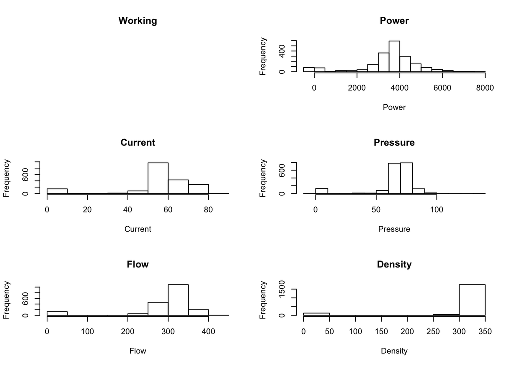

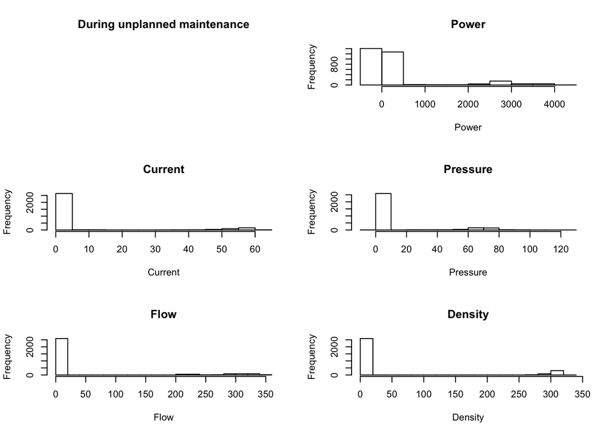

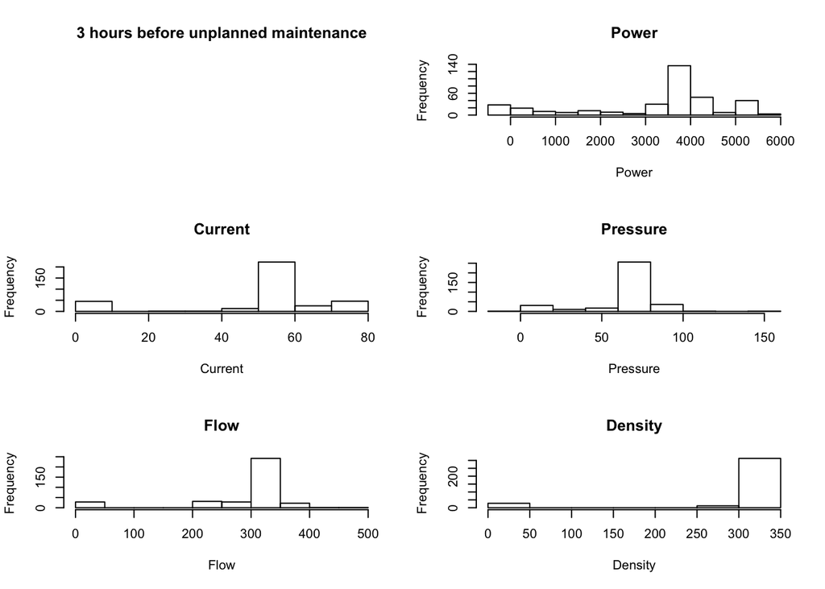

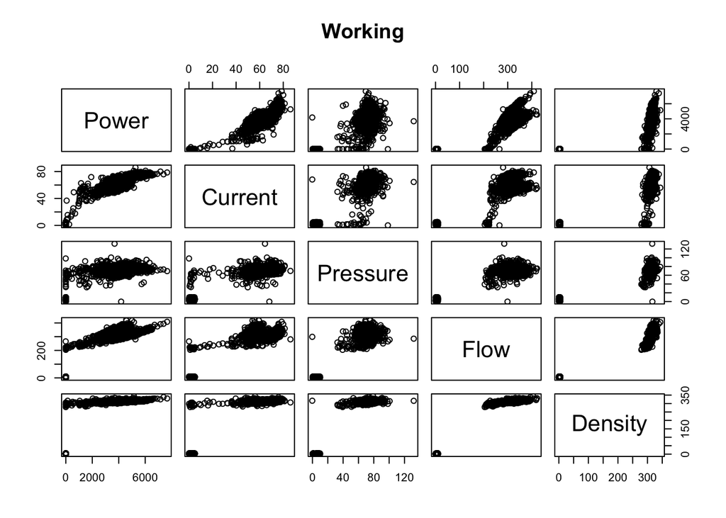

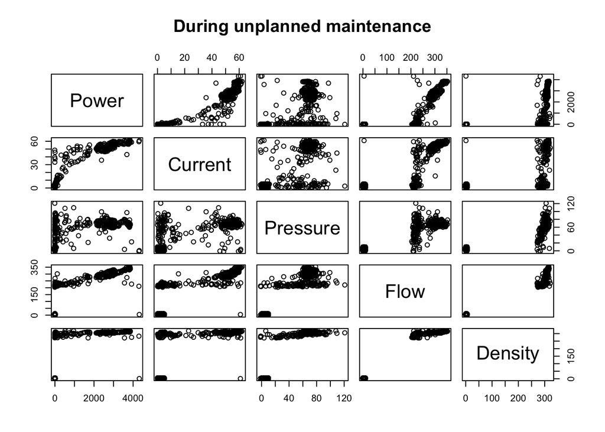

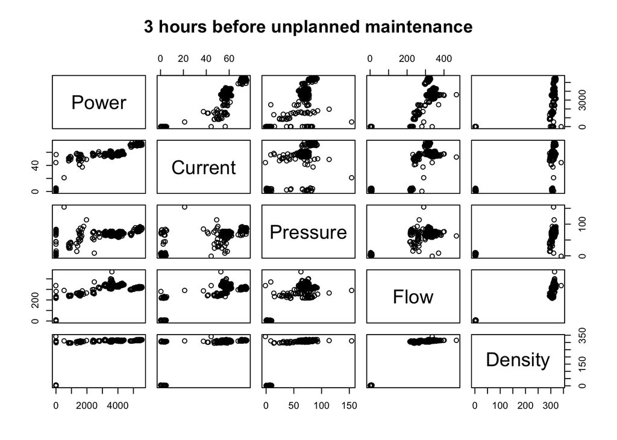

   *Then try a few machine learning algorithms to see what sort of prediction accuracy we can get*
   1. Convert outcome (working or 3 hr prior to outage) to logistic
      - Simplifies initial runs of machine learning algorithms, more complex classifiaction schemes for specific types of unplanned maintenance may be desired by client and possible if the type of outage is frequent and we have sufficient data
   2. Split data into training and test sets
   3. Try SVM
      - Check whether this is an acceptable level of accuracy etc with client eg check how differently they weight false positives vs false negatives (both >50k/hr but likely to have very different durations).
   4. Try neural net
      - Check accuracy etc…

   ### Support Vector Machine

   ```
   ##
   ## Call:
   ## svm(formula = y ~ ., data = df.train)
   ##
   ##
   ## Parameters:
   ##    SVM-Type:  eps-regression
   ##  SVM-Kernel:  radial
   ##        cost:  1
   ##       gamma:  0.1666667
   ##     epsilon:  0.1
   ##
   ##
   ## Number of Support Vectors:  392
   ```

   ```
   ## [1] "Threshold set to 0.45"
   ##       FALSE TRUE Sum
   ## FALSE   111   44 155
   ## TRUE     31  110 141
   ## Sum     142  154 296
   ##                    Results
   ## accuracy          74.66216
   ## misclassification 25.33784
   ## prevalence        47.63514
   ## precision         71.42857
   ## true.pos          78.01418
   ## false.pos         28.38710
   ## true.neg          71.61290
   ## [1] "Threshold set to 0.5"
   ##       FALSE TRUE Sum
   ## FALSE   118   37 155
   ## TRUE     46   95 141
   ## Sum     164  132 296
   ##                    Results
   ## accuracy          71.95946
   ## misclassification 28.04054
   ## prevalence        47.63514
   ## precision         71.96970
   ## true.pos          67.37589
   ## false.pos         23.87097
   ## true.neg          76.12903
   ## [1] "Threshold set to 0.55"
   ##       FALSE TRUE Sum
   ## FALSE   123   32 155
   ## TRUE     59   82 141
   ## Sum     182  114 296
   ##                    Results
   ## accuracy          69.25676
   ## misclassification 30.74324
   ## prevalence        47.63514
   ## precision         71.92982
   ## true.pos          58.15603
   ## false.pos         20.64516
   ## true.neg          79.35484
   ```

### Neural Network

   ```
   ## [1] "Threshold set to 0.45"
   ##       TRUE Sum
   ## FALSE  155 155
   ## TRUE   141 141
   ## Sum    296 296
   ##                 Results
   ## prevalence  47.63513514
   ## precision   47.63513514
   ## true.pos   100.00000000
   ## false.pos  100.00000000
   ## [1] "Threshold set to 0.475"
   ##       TRUE Sum
   ## FALSE  155 155
   ## TRUE   141 141
   ## Sum    296 296
   ##                 Results
   ## prevalence  47.63513514
   ## precision   47.63513514
   ## true.pos   100.00000000
   ## false.pos  100.00000000
   ## [1] "Threshold set to 0.5"
   ##       FALSE Sum
   ## FALSE   155 155
   ## TRUE    141 141
   ## Sum     296 296
   ##                 Results
   ## prevalence  47.63513514
   ## true.neg   100.00000000
   ```

      In contrast, the neural network had a poor accuracy (~45%) regardless of the number of hidden layers (tried 2-4 layers) and the number of hidden units in each layer (tried 7-20). NB the rule of thumb is to use a few more units in each layer as there are parameters in the dataset (5 in this case) and generally you start with the same number of units in each layer. In general, the more layers and more units your neural net has, the better it will perform - but I have seen it do much better on fewer observations (rows) albeit with more parameters (typically 400). At this stage it looks like SVM outperforms neural network, and there are certainly additional ways to optimised the SVM based on the client’s needs - but you get how I would approach this problem.

      There are a couple additional caveates to check that I have learnt through experience - implementation testing is crucial. We would need to determine how this data might feed into a script like this - which includes cleaning, evaluation and preditcting the outcome ie whether preventative maintenance is recommended or not. For example, parts of this script need to be generalised depending on what aspects of the data change (number/type of measurement parameters). The processes for exporting, importing, and then alerting in real time need to be worked through (discussed with client, designed, tested, optimised). Final ‘success’ (ie achieving the Ideal Situation’) needs to be monitored and the process/scripts/algorithms optmised as needed.

## Question 7

What possible problems do you think can exist in a dataset like this?

```
##   Start.date         Start.time
##  Length:43          Length:43
##  Class :character   Class :character
##  Mode  :character   Mode  :character
##
##
##
##
##   Actual.Mins
##  Min.   :780s (~13 minutes)
##  1st Qu.:5670s (~94.5 minutes)
##  Median :19260s (~321 minutes)
##  Mean   :18870.6976744186s (~314.51 minutes)
##  3rd Qu.:28230s (~470.5 minutes)
##  Max.   :43200s (~720 minutes)
##
##                               Comment  Type.of.maintenance
##  bearing failures                 :8   Planned  : 6
##  low gland water flow             :7   Unplanned:37
##  CFP failure                      :6
##  connection & obstruction problems:6
##  cracked casing                   :5
##  broken shut-off valves           :3
##  (Other)                          :8
##      Start                     Old.Event
##  Min.   :2015-01-25 06:00:00   Mode :logical
##  1st Qu.:2015-04-27 23:25:00   FALSE:30
##  Median :2015-10-06 06:00:00   TRUE :13
##  Mean   :2015-08-06 09:53:23   NA's :0
##  3rd Qu.:2015-10-16 15:19:00
##  Max.   :2016-01-25 22:59:00
##
```

```
##      Date               Time               Power
##  Length:197294      Length:197294      Min.   : -11.86432
##  Class :character   Class :character   1st Qu.:3176.09177
##  Mode  :character   Mode  :character   Median :3675.59390
##                                        Mean   :3458.43771
##                                        3rd Qu.:4134.08127
##                                        Max.   :7729.11870
##     Current               Pressure              Flow
##  Min.   : 0.00002914   Min.   :-12.02706   Min.   :  0.0010084
##  1st Qu.:53.62524710   1st Qu.: 64.17586   1st Qu.:290.2863517
##  Median :57.39167787   Median : 69.24895   Median :312.5656333
##  Mean   :54.93228855   Mean   : 64.60696   Mean   :289.7736833
##  3rd Qu.:65.87635552   3rd Qu.: 74.04917   3rd Qu.:332.8028372
##  Max.   :86.22961637   Max.   :184.81991   Max.   :467.2680024
##     Density             date.time
##  Min.   :  0.000348   Min.   :2015-01-01 00:00:00
##  1st Qu.:306.010543   1st Qu.:2015-04-16 18:00:45
##  Median :310.096597   Median :2015-07-31 12:01:30
##  Mean   :285.563900   Mean   :2015-07-31 20:35:28
##  3rd Qu.:314.374412   3rd Qu.:2015-11-15 05:59:15
##  Max.   :360.973297   Max.   :2016-02-29 00:00:00
```

```
##            Date       Time    Power     Current     Pressure        Flow
## 29811 6/03/2015 2:24:00 AM 4011.905 70.17406935 -12.02706077 297.7703883
##           Density           date.time
## 29811 330.2415975 2015-03-06 02:24:00
```

```
##             Date       Time     Power     Current     Pressure        Flow
## 12581 27/01/2015 5:00:00 AM 5330.0161 71.14978783 -1.240520312 320.4008706
## 12655 27/01/2015 8:42:00 AM 5790.4604 70.18292682 -4.001439777 350.8681906
## 12840 27/01/2015 5:57:00 PM 5871.8726 76.96579630 -3.489982165 339.2320145
## 12853 27/01/2015 6:36:00 PM 5902.6860 78.33177074 -1.958696176 352.8640755
## 12895 27/01/2015 8:42:00 PM 5759.2871 72.24053843 -2.153396031 346.5621304
## 12897 27/01/2015 8:48:00 PM 5801.1606 74.72524360 -2.666081965 325.0627652
##           Density           date.time
## 12581 311.2071758 2015-01-27 05:00:00
## 12655 317.1219507 2015-01-27 08:42:00
## 12840 312.5586076 2015-01-27 17:57:00
## 12853 315.2031024 2015-01-27 18:36:00
## 12895 312.3560768 2015-01-27 20:42:00
## 12897 312.5817587 2015-01-27 20:48:00
```

```
## [1] Date      Time      Power     Current   Pressure  Flow      Density
## [8] date.time
## <0 rows> (or 0-length row.names)
```

```
##             Date       Time Power     Current      Pressure          Flow
## 8758  19/01/2015 5:51:00 AM   -10 3.141002553  90.569778790 227.196342300
## 8771  19/01/2015 6:30:00 AM    -8 1.756257308  69.736439870 237.423091600
## 8773  19/01/2015 6:36:00 AM    -6 0.211693994  57.901553460 226.767339700
## 8774  19/01/2015 6:39:00 AM    -9 0.581182345  65.077088930 221.952790700
## 8776  19/01/2015 6:45:00 AM    -7 0.355443666 174.232746500 285.318560900
## 11617 25/01/2015 4:48:00 AM    -9 1.481844937   7.886880125   5.111407182
##             Density           date.time
## 8758  312.060125400 2015-01-19 05:51:00
## 8771  313.135719500 2015-01-19 06:30:00
## 8773  313.232784900 2015-01-19 06:36:00
## 8774  303.520522300 2015-01-19 06:39:00
## 8776  341.729499700 2015-01-19 06:45:00
## 11617   3.375287144 2015-01-25 04:48:00
```

```
##             Date        Time Power     Current    Pressure        Flow
## 11648 25/01/2015  6:21:00 AM     0 0.576856198 1.487930518 8.002249452
## 11674 25/01/2015  7:39:00 AM     0 3.658773434 4.401330161 8.000024289
## 11694 25/01/2015  8:39:00 AM     0 4.577475693 7.690773956 4.551869531
## 11724 25/01/2015 10:09:00 AM     0 0.629562070 9.990047764 1.813214541
## 11726 25/01/2015 10:15:00 AM     0 3.254335009 4.749622049 5.794136450
## 11742 25/01/2015 11:03:00 AM     0 1.449897625 8.019076470 7.645217369
##           Density           date.time
## 11648 4.309599746 2015-01-25 06:21:00
## 11674 0.420007084 2015-01-25 07:39:00
## 11694 0.388375514 2015-01-25 08:39:00
## 11724 0.805507916 2015-01-25 10:09:00
## 11726 3.226135864 2015-01-25 10:15:00
## 11742 4.202872150 2015-01-25 11:03:00
```

For the maintenance data: ‘Comments’ field might not be standardised (ie different technicians may use different terms for same issue) or could have simple typo’s  
One maintenance event may involve more than one problem **Duplicate entries - the biggest problem I faced with this data set were the duplicate entries for maintenance events - where all parameters were equal except for the “Actual.Mins” ie outage duration. I had to remove these (keeping the longest duration entry) before I could join the maintenance and operations data together.